# How have the CPI and its components changed over the last few years?

Aditi Lapasia, Diego Alfaro Legonia, Edgar Pon, Ivy Liu, Teen Ho Nicholas Ching, Roberto Keaney, Susan Wang

# 1 Change in CPI and it’s components

You can find [CPI components at FRED](https://fredaccount.stlouisfed.org/public/datalist/843). You should adapt the code from German polls to scrape the FRED website and pull all of the CPI components into a vector. FIY, the list of components is the second table in that webpage.

## 1.1 Order components so the higher the yearly change, the earlier does that component appear.

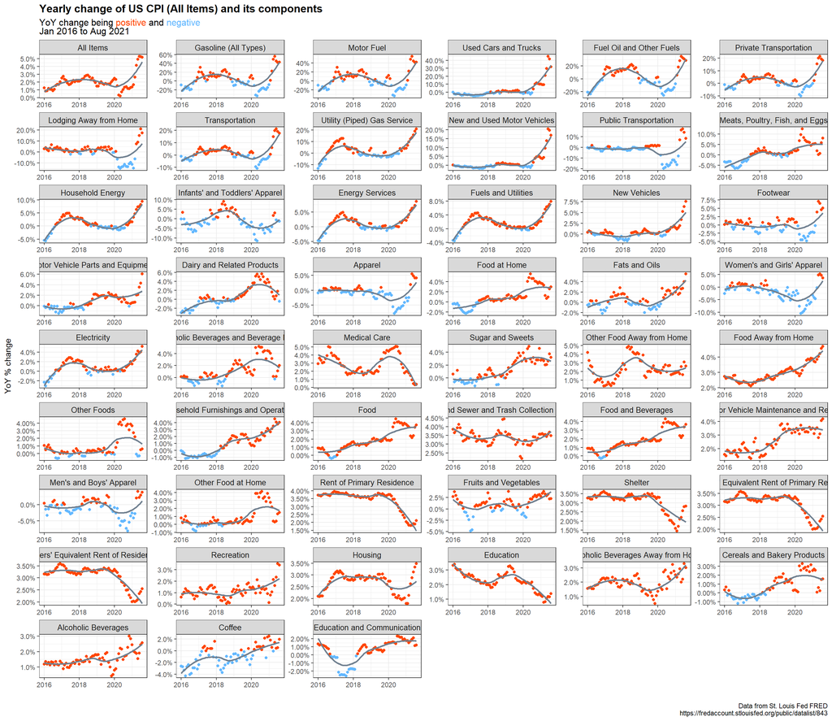

```r
CPI_data_1 <- read_csv(here::here("data","cpi_data.csv"))

start <- "Consumer Price Index for All Urban Consumers: "
end <- " in U.S. City Average"

for(i in 1:18783)
{
CPI_data_1[i,4] <- strsplit(strsplit(CPI_data_1$title[i], start)[[1]][2], end)[[1]][1]
}

library(lubridate)
CPI_data_2 <- CPI_data_1 %>%
              mutate(year = year(date)) %>%
              select(component,date,title,value,year) %>%
              filter(year>=2015) %>%
              group_by(component) %>%
              mutate(year_change = value/lag(value, 12) - 1)

CPI_data_3 <- CPI_data_2 %>%
              group_by(date, component, year_change) %>%
              summarize (date, component, title, year_change)

CPI_data_4 <- CPI_data_3[613:nrow(CPI_data_3),]  %>%
              group_by(component) %>%
              mutate (maximum = max(year_change)) %>%
              summarise(component, date, title, year_change, maximum) %>%
              na.omit()

CPI_data_for_plot <- CPI_data_4 %>%
                      arrange(desc(maximum)) %>%
                      arrange(factor(title, levels = c("All Items")))

cpi_plot <- ggplot(CPI_data_for_plot, aes(x = date, y = year_change)) +
            geom_point(color = ifelse(CPI_data_for_plot$year_change<0,"steelblue1","orangered")) +
            facet_wrap(~factor(CPI_data_for_plot$title, levels = unique(CPI_data_for_plot$title)), ncol = 6, scales = "free")+
            geom_smooth(se = FALSE, color = "slategrey") +
            theme_bw()+
            scale_y_continuous(labels = scales::percent) +
            labs(title = "Yearly change of US CPI (All Items) and its components",
            subtitle = "<span style = 'font-size:12pt'>YoY change being <span style = 'color: orangered;'>positive</span> and <span style = 'color:       steelblue1;'>negative</span><br>Jan 2016 to Aug 2021",
             x = " ",
             y= "YoY % change",
             caption = "Data from St. Louis Fed FRED
    https://fredaccount.stlouisfed.org/public/datalist/843")+
            theme(plot.title = element_text(size=14, face = "bold"), plot.subtitle = element_markdown(size= 12), strip.text = element_text(size=10)) +
            NULL

cpi_plot
```

## 1.2 Choose a smaller subset of the components you have and only list the major categories (Housing, Transportation, Food and beverages, Medical care, Education and communication, Recreation, and Apparel), sorted according to their relative importance?

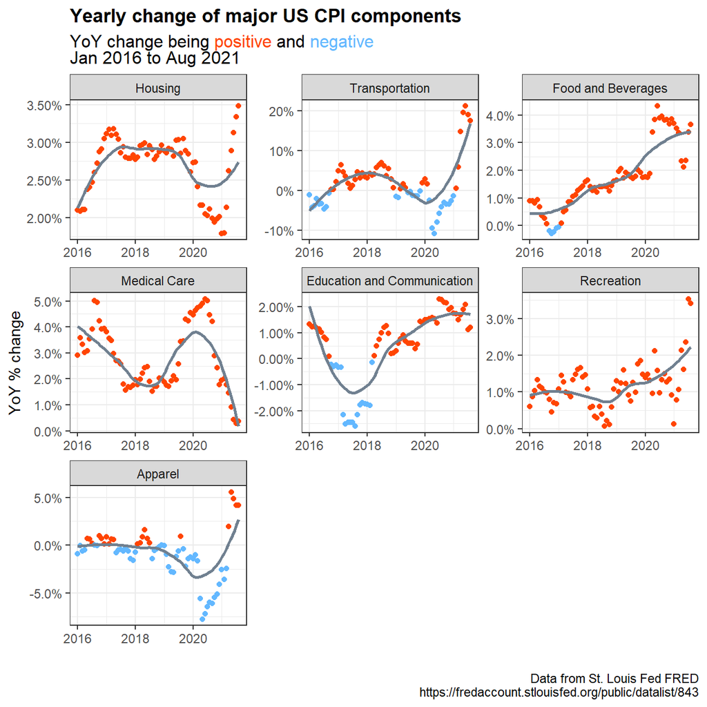

```r
library(dplyr)

subset_CPI <- subset(CPI_data_for_plot, title =="Housing" |
       title =="Transportation" |
       title =="Food and Beverages" |
       title =="Medical Care" |
       title =="Education and Communication" |
       title =="Recreation" |
       title =="Apparel")

major_components <- subset_CPI %>%
                    arrange(factor(title, levels = c("Housing","Transportation", "Food and Beverages", "Medical Care","Education and Communication","Recreation","Apparel")))


major_category_plot<- ggplot(major_components, aes(x = date, y = year_change)) +
                      geom_point(color = ifelse(major_components$year_change<0,"steelblue1","orangered")) +
                      facet_wrap((~factor(major_components$title, levels = unique(major_components$title))), scales = "free")+
                      geom_smooth(se = FALSE, color = "slategrey") +
                      theme_bw()+
                      scale_y_continuous(labels = scales::percent) +
                      labs(title = "Yearly change of major US CPI components",
                      subtitle = "<span style = 'font-size:12pt'>YoY change being <span style = 'color: orangered;'>positive</span> and <span style = 'color: steelblue1;'>negative</span><br>Jan 2016 to Aug 2021",
                      x = " ",
                      y= "YoY % change",
                      caption = "Data from St. Louis Fed FRED
https://fredaccount.stlouisfed.org/public/datalist/843")+
                      theme(plot.title = element_text(face = "bold"), plot.subtitle = element_markdown( ), strip.text = element_text(size=8.5)) +
                      NULL

major_category_plot
```

**Comment:**

Given the current post-pandemic economy, many investors and businesses, in general, are very concerned with how inflation will impact the global economy. Although there is no consensus on how inflation will progress, some argue that the current uncontrolled inflation, that can be observed in most U.S. CPI components such as Food and Beverages, Apparel and Recreation, is due to a mismatch in supply and demand caused by the global pandemic and the unexpected increase in demand, particularly from the United States. Also, these components are known to be quite cyclical, and given the current economic recovery, it’s normal to assume they will suffer higher inflation.

Other components such as Medical Care and Education and Communication are more neutral when it comes to economic growth, as people will need access to these services regardless of the state of the economy. Furthermore, a more moderate inflation growth trend can be expected for these components. Medical Care inflation growth declined significantly over the last year. This can be explained by the decrease in COVID-19 cases and hospitalizations.

The poor economic outlook during the start of the pandemic influenced many key manufacturing countries to understock their inventories. This understocking combined with an extraordinary increase in demand has depleted inventory stocks worldwide, increasing the price of many commodities and products. Once the supply cycle can catch up with the current level of demand, this mismatch will ease, and so could inflation, possibly without the need for Central Bank intervention.